# Solution to Exercise 7.3

### 02409 Multivariate Statistics

`Week C`

**Principal Component Analysis on Beef characterization**

In this exercise you will work on data reflecting different aspects of meat, both chemical, physical and sensory attributes. The example comes from the paper [G. Destefanis, M.T. Barge A. Brugiapaglia and S.Tassone (2000): The use of principal component analysis (PCA) to characterize beef. Meat Science 56(2000), pp 255-259.]. The aim is to study the relationship between chemical, physical and sensory variables measured on meat from young bulls of five different breeds. Those were:

- Hypertrophied Piemontese n=23
- Normal Piemontese n=12
- Hypertrophied Piemontese x Friesian Crossbreed n=10
- Friesian n=11
- Belgian blue and white n=23

18 different measurements were taken on each animal. The chemical measurements are:

1. pH (pH-value)
2. Water
3. Protein
4. EtherExt ( ether extract - related to fat content)
5. Hydroxy (hydroxyproline content, i.e. cartilage)
6. CollaSol (heat-solubility of collagen)

The physical parameters are:

7. Lightn (lightness)
8. Hue ( relates to the color of the meat)
9. Driploss
10. CookLoss (cooking loss)
11. WBshear (Warner-Bratzler shear, which gives an indication of the tenderness of the meat)

And finally seven different sensory parameters (A, Te, Tf, Tr, Ji, Js, Oa) were assesed using a trained panel.

12. Appear (appearance)
13. EaseSink (ease of sinking)
14. Friabil (friability)
15. Residue (after chewing)
16. InJuice (initial juiciness)
17. SusJuice (sustained juiciness)
18. OvAcc (overall acceptability)

The correlation matrix is found as:

```r
Beef <- data.frame("pH" = c(1,rep(0,17)),
  "Water" = c(0.09,1,rep(0,16)),
  "Protein"  = c(0.28,-0.4,1,rep(0,15)),
  "EtherExt" = c(-0.28,-0.16,-0.56,1,rep(0,14)),
  "Hydroxy" = c(-0.33,-0.08,-0.55,0.59,1,rep(0,13)),
  "CollaSol" = c(-0.08,-0.01,-0.03,0.05,0.16,1,rep(0,12)),
  "Lightn" = c(-0.02,0.03,0.34,-0.31,-0.48,-0.02,1,rep(0,11)),
  "Hue" = c(-0.33,-0.23,-0.47,0.4,0.62,-0.03,-0.21,1,rep(0,10)),
  "DripLoss" = c(0.01,0.18,-0.07,0.08,-0.12,-0.1,0.25,-0.13,1,rep(0,9)),
  "CookLoss" = c(-0.38,0.15,-0.64,0.44,0.66,-0.01,-0.45,0.65,0.03,1,rep(0,8)),
  "WBshear" = c(-0.26,-0.01,-0.63,0.42,0.72,-0.03,-0.55,0.67,-0.11,0.73,1,rep(0,7)),
  "Appear" = c(0.1,-0.003,0.25,-0.42,-0.33,-0.19,0.35,0.07,0.02,-0.18,-0.28,1,rep(0,6)),
  "EaseSink" = c(0.17,-0.16,0.27,-0.11,-0.26,0.01,0.19,-0.19,-0.02,-0.36,-0.38,0.24,1,rep(0,5)),
  "Friabil" = c(0.1,-0.17,0.2,-0.09,-0.22,0.06,0.19,-0.1,-0.03,-0.31,-0.32,0.27,0.93,1,rep(0,4)),
  "Residue"  = c(0.08,-0.19,0.23,-0.13,-0.24,-0.02,0.2,-0.1,-0.02,-0.32,-0.33,0.33,0.91,0.94,1,rep(0,3)),
  "InJuice" = c(0.08,-0.08,0.03,-0.004,-0.05,0.05,-0.06,-0.03,-0.13,-0.12,-0.1,0.16,0.69,0.72,0.72,1,rep(0,2)),
  "SusJuice" = c(0.01,-0.09,-0.004,-0.01,-0.02,0.03,-0.02,0.08,-0.15,-0.07,-0.03,0.24,0.66,0.7,0.7,0.93,1,rep(0,1)),
  "OvAcc" = c(0.13,-0.13,0.21,-0.09,-0.22,0.07,0.22,-0.14,-0.01,-0.34,-0.37,0.31,0.92,0.92,0.91,0.8,0.79,1)
)
Beef = Beef + t(Beef) - diag(1,18,18)
```

**1. How much variation in the data does the first four PCs explain?**

```r
# PCA with eigendecomposition:
pc <- eigen(Beef)
var <- pc$values
p <- pc$vectors


# Table with Ev, Proportion and Cumulative Variance:
varPC <- var/sum(var)
cumu = c(1:18)
for (i in 1:18){
  cumu[i] = sum(varPC[1:i])
}
results <- data.frame("eigenvalues"=var,"proportion"=varPC,
                      "cumulative" = cumu)
print("Eigenvalues of the Correlation matrix:")
results
```

```
## [1] "Eigenvalues of the Correlation matrix:"
```

```
##    eigenvalues  proportion cumulative
## 1   6.11394026 0.339663348  0.3396633
## 2   3.71442057 0.206356698  0.5460200
## 3   1.43723015 0.079846119  0.6258662
## 4   1.35100005 0.075055558  0.7009217
## 5   1.20962246 0.067201248  0.7681230
## 6   1.00247459 0.055693033  0.8238160
## 7   0.71917200 0.039954000  0.8637700
## 8   0.55560012 0.030866673  0.8946367
## 9   0.46178302 0.025654612  0.9202913
## 10  0.39193522 0.021774179  0.9420655
## 11  0.28453438 0.015807466  0.9578729
## 12  0.25195903 0.013997724  0.9718707
## 13  0.15378240 0.008543467  0.9804141
## 14  0.12251392 0.006806329  0.9872205
## 15  0.08116546 0.004509192  0.9917296
## 16  0.05559572 0.003088651  0.9948183
## 17  0.05087885 0.002826603  0.9976449
## 18  0.04239179 0.002355099  1.0000000
```

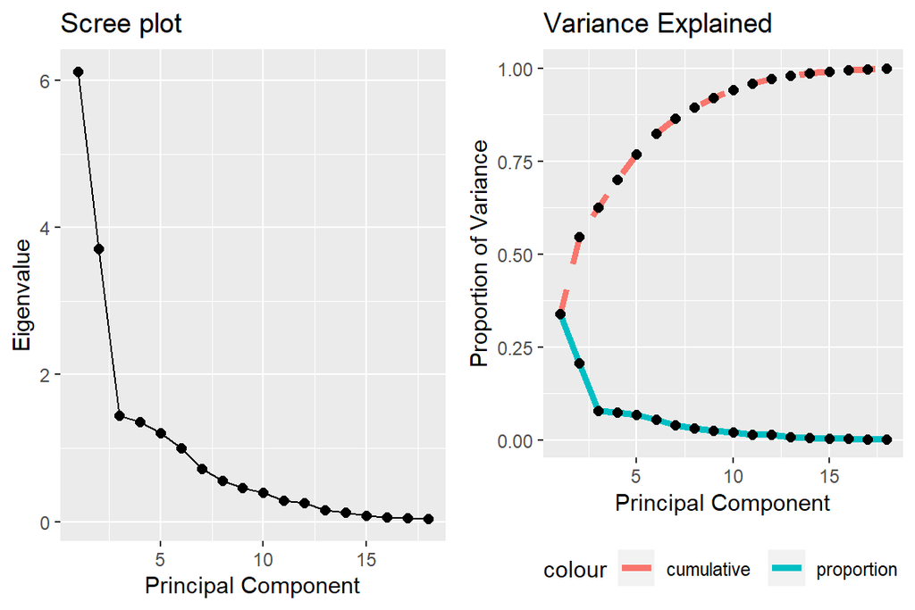

```r
#Scree Plot
Scree = ggplot(results,aes(x=c(1:18),y=eigenvalues,group=1))+
    geom_line()+
    geom_point(size=2)+
    labs(x='Principal Component',y='Eigenvalue')+
    ggtitle('Scree plot')

# Variance Explained plot
Var = ggplot(results,aes(x=c(1:18),group=1))+
    geom_line(aes(y=cumulative,col = 'cumulative'),linetype = 'dashed',lwd=1.5)+
    geom_line(aes(y=proportion,col = 'proportion'),lwd=1.5)+
    geom_point(aes(y=cumulative),size=2)+
    geom_point(aes(y=proportion),size=2)+
    labs(x='Principal Component',y='Proportion of Variance')+
    theme(legend.position='bottom')+
    ggtitle('Variance Explained')

Scree_Var = list(Scree,Var)
ggarrange(plotlist = Scree_Var,ncol=2)
```

We see that the first 4 principal components explain 70.09% of the total variation.

The scree plot indicates that one should only retain 2 components since the plot flattens out after component no 2.

**2. Look at the principle components. What kind of parameters dominate the first two PCs?**

**Note: For consistency of description between the outputs in SAS and in R, PC1 and PC2 are multiplied by -1.**

```r
data.frame("Variables" = names(Beef),"PC1" = -p[,1],"PC2" = -p[,2])
```

```
##    Variables          PC1         PC2
## 1         pH  0.120405355 -0.16142955
## 2      Water -0.057400044 -0.08214518
## 3    Protein  0.220418572 -0.27607063
## 4   EtherExt -0.168724192  0.28436221
## 5    Hydroxy -0.237765363  0.32911396
## 6   CollaSol -0.003805396  0.05255716
## 7     Lightn  0.167782295 -0.21776561
## 8        Hue -0.174536737  0.31579293
## 9   DripLoss -0.003860330 -0.09036238
## 10  CookLoss -0.265005784  0.27795351
## 11   WBshear -0.270307049  0.29379173
## 12    Appear  0.173938554 -0.05211049
## 13  EaseSink  0.348332364  0.18423710
## 14   Friabil  0.340431118  0.22287599
## 15   Residue  0.344411290  0.21100503
## 16   InJuice  0.267428661  0.30715873
## 17  SusJuice  0.254236170  0.32646165
## 18     OvAcc  0.352745290  0.21994109
```

The first principal component has relatively large weights on the sensory panel variables plus on protein on one side, and numerically relatively large negative values on EtherExt (related to fat), Hydroxy (related to connective tissue), CookLoss, and on WBshear (related to tenderness) on the other side. Thus a large value will correspond to a meat sample of high general quality, and a low score will correspond to a sample with a low general quality.

The second component is still characterized by positive values on the sensory panel variables, although now with stronger emphasis on the juiciness variables and a negligible (but negative) score on appearance. The signs of the different physical/chemical variables have changed such that the component measures a contrast between meat that scores well by a panel and scores ‘badly’ from a physical/chemical ‘point of view’ and vice versa.

**3. In what way can this be related to the correlation matrix?**

From the correlation matrix we see that e.g the tenderness parameter WBshear is negatively correlated with all sensory panel variables. Therefore it is expected that WBshear will enter with a negative weight in a ‘general quality’ component.

**4. It may be expensive to measure all these variables. If some of them are redundant, we might want to exclude some of them from future studies. Give a suggestion/strategy for exclusion of variables.**

Some of the variables are very correlated. For instance we see that Susjuice and Injuice have a correlation coefficient that is 0.93 showing a substantial redundancy between the information described by these two variables. Therefore it is expected that they will enter the analyses in a very similar way, and consequently one might consider not evaluating one of them in a possible coming study.